# PB-ROE：技术报告

蓝海

彭莉

# PB和ROE

## PB的历史演进

PB勾结了股票市场上的两个信号：

- Price（价格）：这是个在市场上只要交易就变化着的快信号；
- Book (会计价值)：这是由会计师依据的会计准则为投资者记录的企业的账面价值，它是由企业的历史活动累积的、会计师周期性更新的慢信号。

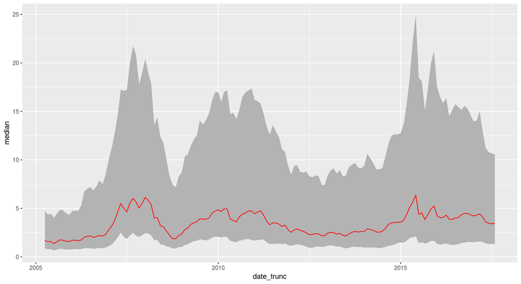

PB全市场历史统计

阴影部分是同期市场上所有股票一月之间的PB值的5%至95%。而红色的线则代表这些PB数值的中位数。不难理解2007年和2015年市场泡沫期间，市场对于股票价格整个的高估，表现在PB值无论是低5%、高的95%还是中位数都整体上扬，伴随市场指数攀顶而到达顶点。更进一步的，如果勾画每个季度市场PB值的概率密度函数，我们也能发现相似的结果。

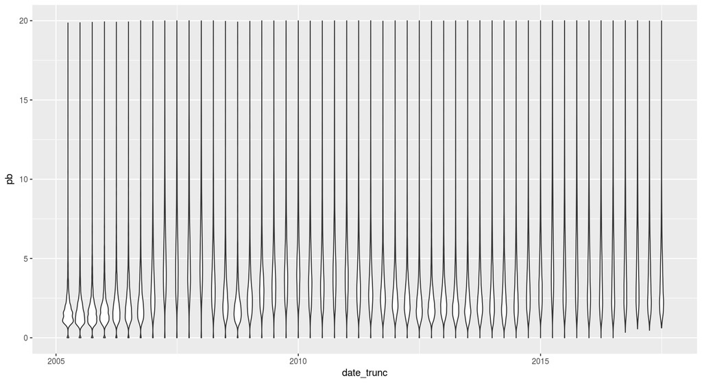

PB全市场历史分布

上图中，我们勾画了每个季度PB值分布的概率密度函数的大致形状与变化，从中可以看出从2007年以来PB的分布基本是单峰的。2010年市场PB值的分布与2007年市场泡沫时候是类似的，这与我们从5%、95%以及中位数曲线上看到的结果是一致的。

有意思的是，2011年的PB估值水平又一次上升到一个几乎与2007年相似的高峰——尽管指数恢复的情况远未能达到前期泡沫时水平，但是PB值却十分接近泡沫时的高点。以上现象可以用股票价格的恢复来解释吗？ 我们看同一时期，沪深300的形态是：

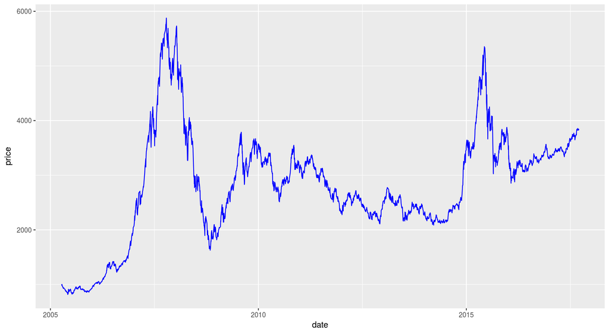

沪深300历史趋势

显然，股票价格是能够部分解释PB的上扬，但是不能解释为什么PB上涨远远超出价格恢复的幅度，而几乎接近泡沫时期的高点。那么是由于每股账面价值（book price per share）恶化的结果吗？

同一时期，上市公司每股账面价值的变化是：

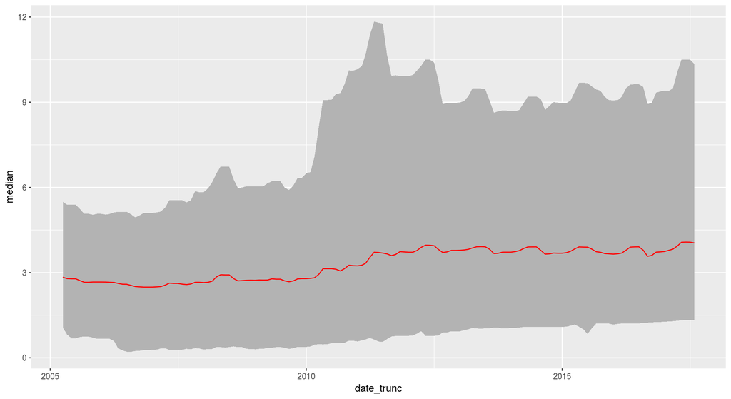

Bps全市场历史统计

整体上，公司每股账面价值呈现温和上升的趋势———随着中国经济的发展，企业在不断的创造和积累价值，当然这个过程中也伴随有部分企业拆股、送股等行为对企业每股账目价值的稀释作用。但是，无论如何，每股账面价值的变化不能解释价格泡沫过后出现的PB“估值泡沫”的发生。我们需要进一步的分析PB变化的原因。

查阅同期的经济政策，不难注意到同期进行4万亿货币放水。获利于大量投资资源类型股票大幅升值，获利与货币宽松，房地产价格飙升，地产股以及相关的周期性股票获益，伴随着货币宽松向股市等虚拟经济扩散，一些弹性较大的中小盘股也枉顾经济基本面而节节攀升。实际上，这是不亚于2007年的资本的狂欢，之所以没有显示在沪深300的指数大幅度的上升（相比较于2007年）是由于当时主要要获益的股票不是沪深300针对的大盘股，而是一些中小盘、周期性、资源型股票。

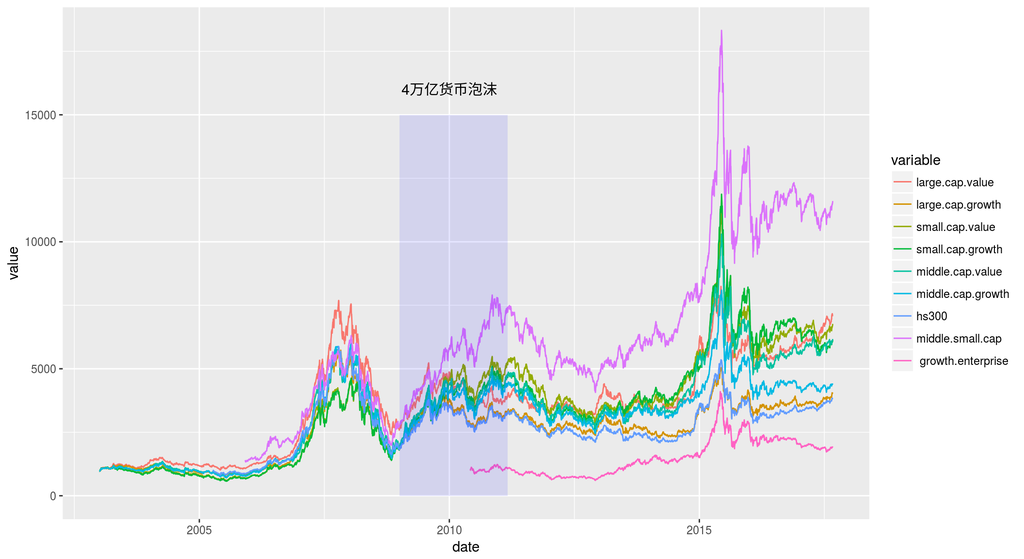

各类股票收益历史趋势

从上图可以看到，中小板块在2011年左右超越2007年，创造了新高。这合理地解释了2011年出现PB估值高点的原因。由此可见，PB值的中位数以及5%和95%的数值带确实能够揭示一些有趣的东西。而这些东西可能会被单一的指数所忽略。

那么市场上常常使用的均值系统用来表征PB信息是否也是有效的呢？市场经常讨论、关注的是PB值的资金加权算术平均，它代表的是市场整体上愿意为上市公司的账目资产支付的价格。考虑到中国股市的特殊性，流通股数的加权平均是首选、其次才是总股数的加权平均。毕竟非流通股，没有实际上的资金消耗需求，因而不能实在的反应市场所给出估值需要付出的代价。

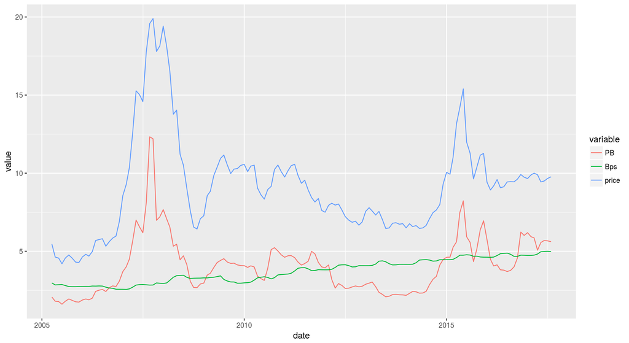

流通权重PB均值全市场历史统计

从上图可以看出加权平均系统的一些缺陷： 1. 无论是平均价格（price）还是平均估值水平（PB）都没有显示2010年左右的中小盘牛市，原因是中小盘在加权平均中所占比重较小。 2. 2016年末至今的漂亮50行情，在平均价格（price）上的反映低于平均估值水平（PB）上的。这种反映在平均价格和平均估值上的波动水平的不一致，在历史上2010年左右也是有体现的。原因是这两次行情都不是全市场的，2010年的行情属于中小板块，此次的行情属于大盘价值股（漂亮50）。因为这些子板块在不同的均值中表现出的影响力是不一样的，所以才出现了平均价格与平均估值的波动幅度不一致的现象。

整体上来讲，在很多金融指标中分位数（quantile）是好于均值系统（mean）的统计方法。